# Mini project - Titanic survivors prediction

December 9, 2016 - 12 minute read -

## Dataset: Titanic survival

*Introductory project of Udacity Machine Learning Nanodegree*

In 1912, the ship RMS Titanic struck an iceberg on its maiden voyage and sank, resulting in the deaths of most of its passengers and crew. In this introductory project, we will explore a subset of the RMS Titanic passenger manifest to determine which features best predict whether someone survived or did not survive.

I think the Titanic dataset is a very good dataset to get started with classification task in Machine Learning as it has historical background. Furthermore, the attributes of the dataset is meaningful and easy to take as an example for many aspect of a machine learning workflow such as pre-processing or missing values. Compared to the Iris dataset, this Titanic daset is a much better choice. There is **11 attributes** for each person in the dataset:

- **Survived**: Outcome of survival (0 = No; 1 = Yes)
- **Pclass**: Socio-economic class (1 = Upper class; 2 = Middle class; 3 = Lower class)
- **Name**: Name of passenger
- **Sex**: Sex of the passenger
- **Age**: Age of the passenger (Some entries contain `NaN`)
- **SibSp**: Number of siblings and spouses of the passenger aboard
- **Parch**: Number of parents and children of the passenger aboard
- **Ticket**: Ticket number of the passenger
- **Fare**: Fare paid by the passenger
- **Cabin** Cabin number of the passenger (Some entries contain `NaN`)
- **Embarked**: Port of embarkation of the passenger (C = Cherbourg; Q = Queenstown; S = Southampton)

## Requirement

This project requires `Python-3.5.2`, `pandas-0.19.1`, `numpy-0.11.2`, and `matplotlib-1.5.3`. Also, the data (csv) and plotting script (python) can be found [here](https://github.com/gear/MLNano/tree/master/part2-titanic/project0_titanic).

First, we import `numpy` for computations and `pandas` for data handling. The fundamental object of `pandas` is a `DataFrame`. In the code below, `full_data` is a pandas `DataFrame`. `DataFrame` object is presented similar to a spreadsheet table (contains rows and columns). Each row is a pandas `Series`. The `.head()` function of a `DataFrame` return the first five rows of the data:

```python
import numpy as np
import pandas as pd

# Data

# RMS Titanic data visualization code
from sys import path
path.append('../src')
from titanic_visualizations_p3 import survival_stats
from IPython.display import display
%matplotlib inline

# Load the dataset
in_file = '../data/titanic_data.csv'
full_data = pd.read_csv(in_file)

# Print the first few entries of the RMS Titanic data
display(full_data.head())
```

|  | PassengerId | Survived | Pclass | Name | Sex | Age | SibSp | Parch | Ticket | Fare | Cabin | Embarked |
| --- | --- | --- | --- | --- | --- | --- | --- | --- | --- | --- | --- | --- |
| 0 | 1 | 0 | 3 | Braund, Mr. Owen Harris | male | 22.0 | 1 | 0 | A/5 21171 | 7.2500 | NaN | S |
| 1 | 2 | 1 | 1 | Cumings, Mrs. John Bradley (Florence Briggs Th... | female | 38.0 | 1 | 0 | PC 17599 | 71.2833 | C85 | C |
| 2 | 3 | 1 | 3 | Heikkinen, Miss. Laina | female | 26.0 | 0 | 0 | STON/O2. 3101282 | 7.9250 | NaN | S |
| 3 | 4 | 1 | 1 | Futrelle, Mrs. Jacques Heath (Lily May Peel) | female | 35.0 | 1 | 0 | 113803 | 53.1000 | C123 | S |
| 4 | 5 | 0 | 3 | Allen, Mr. William Henry | male | 35.0 | 0 | 0 | 373450 | 8.0500 | NaN | S |

## Data preprocessing

Since we’re interested in the outcome of survival for each passenger or crew member, we can remove the **Survived** feature from this dataset and store it as its own separate variable `outcomes`. We will use these outcomes as our prediction targets.

```python
# Store the 'Survived' feature in a new variable and
# remove it from the dataset
outcomes = full_data['Survived']
data = full_data.drop('Survived', axis = 1)

# Show the new dataset with 'Survived' removed
display(data.head())
```

|  | PassengerId | Pclass | Name | Sex | Age | SibSp | Parch | Ticket | Fare | Cabin | Embarked |
| --- | --- | --- | --- | --- | --- | --- | --- | --- | --- | --- | --- |
| 0 | 1 | 3 | Braund, Mr. Owen Harris | male | 22.0 | 1 | 0 | A/5 21171 | 7.2500 | NaN | S |
| 1 | 2 | 1 | Cumings, Mrs. John Bradley (Florence Briggs Th... | female | 38.0 | 1 | 0 | PC 17599 | 71.2833 | C85 | C |
| 2 | 3 | 3 | Heikkinen, Miss. Laina | female | 26.0 | 0 | 0 | STON/O2. 3101282 | 7.9250 | NaN | S |
| 3 | 4 | 1 | Futrelle, Mrs. Jacques Heath (Lily May Peel) | female | 35.0 | 1 | 0 | 113803 | 53.1000 | C123 | S |
| 4 | 5 | 3 | Allen, Mr. William Henry | male | 35.0 | 0 | 0 | 373450 | 8.0500 | NaN | S |

The very same sample of the RMS Titanic data now shows the **Survived** feature removed from the DataFrame. Note that `data` (the passenger data) and `outcomes` (the outcomes of survival) are now *paired*. That means for any passenger `data.loc[i]`, they have the survival outcome `outcome[i]`.

## Evaluation method

To measure the performance of our predictions, we need a metric to score our predictions against the true outcomes of survival. Since we are interested in how *accurate* our predictions are, we will calculate the proportion of passengers where our prediction of their survival is correct. The code cell below to create our `accuracy_score` function and test a prediction on the first five passengers.

```python
def accuracy_score(truth, pred):
    """ Returns accuracy score for input truth and predictions. """

    # Ensure that the number of predictions matches number of outcomes
    if len(truth) == len(pred):

        # Calculate and return the accuracy as a percent
        return "Predictions have an accuracy of {:.2f}%." \
                .format((truth == pred).mean()*100)

    else:
        return "Number of predictions does not match number of outcomes!"

# Test the 'accuracy_score' function
predictions = pd.Series(np.ones(5, dtype = int))
print(accuracy_score(outcomes[:5], predictions))
```

```
Predictions have an accuracy of 60.00%.
```

## Making naive predictions

If we were told to make a prediction about any passenger aboard the RMS Titanic who we did not know anything about, then the best prediction we could make would be that they did not survive. This is because we can assume that a majority of the passengers as a whole did not survive the ship sinking. The function below will always predict that a passenger did not survive. It is always useful to have a *ZeroR* model which makes a default prediction. Based on such naive model, we know roughly what should we expect from our (more powerful) machine learning model.

```python
def predictions_0(data):
    """
    Model with no features. Always predicts
    a passenger did not survive.
    """

    predictions = []
    for _, passenger in data.iterrows():

        # Predict the survival of 'passenger'
        predictions.append(0)

    # Return our predictions
    return pd.Series(predictions)

# Make the predictions
predictions = predictions_0(data)
```

```python
print(accuracy_score(outcomes, predictions))
```

```
Predictions have an accuracy of 61.62%.
```

The prediction for a naive model which always says the passenger did not survive is 61.62%, which means we should expect our model later to perform well above this bar.

## Analyze the data to find a better model

Let’s take a look at whether the feature **Sex** has any indication of survival rates among passengers using the `survival_stats` function. This function is defined in the `titanic_visualizations.py` Python script included with this project. The first two parameters passed to the function are the RMS Titanic data and passenger survival outcomes, respectively. The third parameter indicates which feature we want to plot survival statistics across. The code cell below plots the survival count wrt the gender of the passenger.

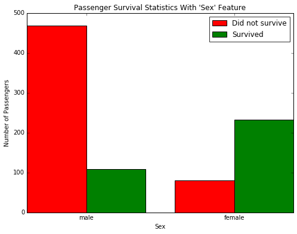

```python
survival_stats(data, outcomes, 'Sex')
```

Examining the survival statistics, a large majority of males did not survive the ship sinking. However, a majority of females *did* survive the ship sinking. Let’s build on our previous prediction: If a passenger was female, then we will predict that they survived. Otherwise, we will predict the passenger did not survive.

```python
def predictions_1(data):
    """ Model with one feature:
            - Predict a passenger survived if they are female. """

    predictions = []
    for _, passenger in data.iterrows():

        # Remove the 'pass' statement below
        # and write your prediction conditions here
        predictions.append(1 if passenger['Sex'] == 'female' else 0)

    # Return our predictions
    return pd.Series(predictions)

# Make the predictions
predictions = predictions_1(data)
```

The accuracy of our new prediction model:

```python
print(accuracy_score(outcomes, predictions))
```

```
Predictions have an accuracy of 78.68%.
```

Using just the **Sex** feature for each passenger, we are able to increase the accuracy of our predictions by a significant margin. Now, let’s consider using an additional feature to see if we can further improve our predictions. Consider, for example, all of the male passengers aboard the RMS Titanic: Can we find a subset of those passengers that had a higher rate of survival? Let’s start by looking at the **Age** of each male, by again using the `survival_stats` function. This time, we’ll use a fourth parameter to filter out the data so that only passengers with the **Sex** ‘male’ will be included.

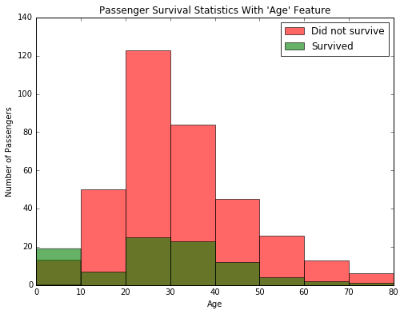

```python
survival_stats(data, outcomes, 'Age', ["Sex == 'male'"])
```

Examining the survival statistics, the majority of males younger then 10 survived the ship sinking, whereas most males age 10 or older *did not survive* the ship sinking. Let’s continue to build on our previous prediction: If a passenger was female, then we will predict they survive. If a passenger was male and younger than 10, then we will also predict they survive. Otherwise, we will predict they do not survive.

```python
def predictions_2(data):
    """
    Model with two features:
        - Predict a passenger survived if they are female.
        - Predict a passenger survived if they are male and younger than 10.
    """

    predictions = []
    for _, passenger in data.iterrows():

        # Remove the 'pass' statement below
        # and write your prediction conditions here
        if passenger['Sex'] == 'female' or passenger.Age < 10:
            predictions.append(1)
        else:
            predictions.append(0)

    # Return our predictions
    return pd.Series(predictions)

# Make the predictions
predictions = predictions_2(data)
```

```python
print(accuracy_score(outcomes, predictions))
```

```
Predictions have an accuracy of 79.35%.
```

Adding the feature **Age** as a condition in conjunction with **Sex** improves the accuracy by a small margin more than with simply using the feature **Sex** alone.

## More powerful model

Now we should analyze the data to find some more powerful rules that achieve at least 80% accuracy.

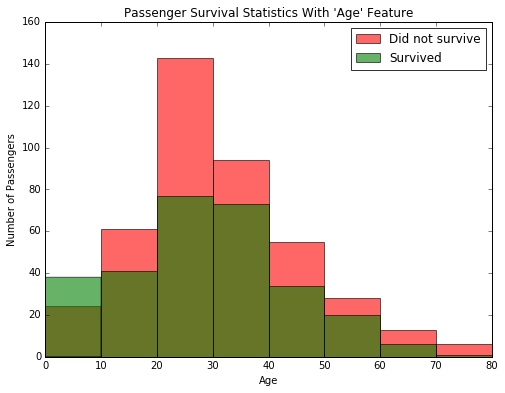

```python
survival_stats(data, outcomes, 'Age')
```

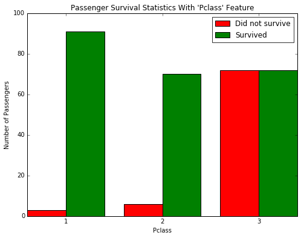

```python
survival_stats(data, outcomes, 'Pclass', ['Sex == "female"'])
```

```python
survival_stats(data, outcomes, 'Pclass', ['Sex == "male"'])
```

[output not shown]

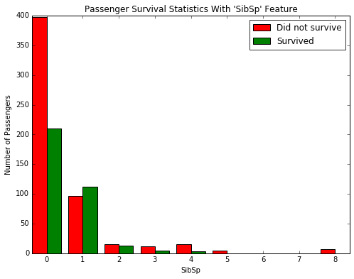

```python
survival_stats(data, outcomes, 'SibSp')
```

```python
def predictions_3(data):
    """
    Model with multiple features. Makes a prediction
    with an accuracy of at least 80%.
    """

    predictions = []
    for _, passenger in data.iterrows():

        # Remove the 'pass' statement below
        # and write your prediction conditions here
        if passenger.Sex == 'female':
            if passenger.Pclass == 3:
                if 20 < passenger.Age < 50:
                    predictions.append(0)
                else:
                    predictions.append(1)
            else:
                predictions.append(1)
        else:
            if passenger.Pclass == 1:
                if passenger.Age < 10 or 20 < passenger.Age < 40:
                    predictions.append(1)
                else:
                    predictions.append(0)
            else:
                predictions.append(0)

    # Return our predictions
    return pd.Series(predictions)

# Make the predictions
predictions = predictions_3(data)
```

```python
print(accuracy_score(outcomes, predictions))
```

```
Predictions have an accuracy of 80.13%.
```

## Conclusion

I think supervised learning can be used as an lazy method for human to tell computer what to do. For example, instead of building a complex concrete model for 30-years crack prediction from data by hand, a civil engineer can assume a generic model and leave the pattern learning for the machine.